# Preprocessing of FTMS LC-MSn data

Authors

Ahlam Mentag

Johannes Rainer

Rebecca Dauwe

# Introduction

In this document, we present all the main steps for analyzing FTMS data, including data visualization, preprocessing, *xcms* preprocessing including retention time alignment. We also plotted the extracted ion chromatograms of some known compounds.

# Data import

We first load all required R packages for the analysis in this document.

```r
library(MsExperiment)
library(Spectra)
library(xcms)
library(readxl)
library(pander)
library(pheatmap)
register(SerialParam())
```

Next we read the LC-MSn data from the mzML data files.

The sample/file information is retrieved from an Excel file *ftms_data_files.xlsx* that must meet the following minimal requirements:

– A column named *data_file* containing the filenames of the *.mzML* files. – A column named *sample_name* with the corresponding sample names. The sample name for blank control files should be `"blank"`. – A column named *sample_id*.

All files should be placed locally within the working directory containing also this file (i.e., *ftms-preprocessing.qmd*). The directory hierarchy is expected to be the following:

– *<my.workdir>/data/mzML*: directory containing all *.mzML* files. – *<my.workdir>/data/sample_data/*: directory containing the Excel file with the sample and file information.

In the following code, *<my.workdir>* is the working directory:

```r
##setwd("C:/Users/amentag/Desktop/Rcodes/RDynLib_ftms")
pth <- getwd()
pth
```

```
[1] "D:/RDynLib_ftms"
```

Now we import our dataset. The `MsExperiment::readMsExperiment()`function creates an `MsExperiment`object, which we will call here `ftms`.

```r
sample_data_ftms <- read_xlsx(
    file.path(pth, "data/sample_data/ftms_data_files.xlsx")) |>
    as.data.frame()
MZML_PATH <- file.path(pth,"data","mzML_cent1")
ftms <- readMsExperiment(file.path(MZML_PATH, sample_data_ftms$data_file),
                         sampleData = sample_data_ftms)
ftms
```

```
Object of class MsExperiment
 Spectra: MS1 (21576) MS2 (21576) MS3 (12266) MS4 (5395)
 Experiment data: 10 sample(s)
 Sample data links:
  - spectra: 10 sample(s) to 60813 element(s).
```

```r
pandoc.table(as.data.frame(sampleData(ftms)), caption = "Data files",
             split.table = Inf, style = "rmarkdown")
```

```
|    &nbsp;     | data_file | sample_name | injection_index | polarity | sample_id | replicate |               spectraOrigin               |
|:-------------:|:---------:|:-----------:|:---------------:|:--------:|:---------:|:---------:|:-----------------------------------------:|
| **S1R1.mzML** | S1R1.mzML |    S1R1     |       NA        |   NEG    |    S1     |     1     | D:\RDynLib_ftms\data\mzML_cent1\S1R1.mzML |
| **S1R2.mzML** | S1R2.mzML |    S1R2     |       NA        |   NEG    |    S1     |     2     | D:\RDynLib_ftms\data\mzML_cent1\S1R2.mzML |
| **S1R3.mzML** | S1R3.mzML |    S1R3     |       NA        |   NEG    |    S1     |     3     | D:\RDynLib_ftms\data\mzML_cent1\S1R3.mzML |
| **S1R4.mzML** | S1R4.mzML |    S1R4     |       NA        |   NEG    |    S1     |     4     | D:\RDynLib_ftms\data\mzML_cent1\S1R4.mzML |
| **S1R5.mzML** | S1R5.mzML |    S1R5     |       NA        |   NEG    |    S1     |     5     | D:\RDynLib_ftms\data\mzML_cent1\S1R5.mzML |
| **S9R1.mzML** | S9R1.mzML |    S9R1     |       NA        |   NEG    |    S9     |     1     | D:\RDynLib_ftms\data\mzML_cent1\S9R1.mzML |
| **S9R2.mzML** | S9R2.mzML |    S9R2     |       NA        |   NEG    |    S9     |     2     | D:\RDynLib_ftms\data\mzML_cent1\S9R2.mzML |
| **S9R3.mzML** | S9R3.mzML |    S9R3     |       NA        |   NEG    |    S9     |     3     | D:\RDynLib_ftms\data\mzML_cent1\S9R3.mzML |
| **S9R4.mzML** | S9R4.mzML |    S9R4     |       NA        |   NEG    |    S9     |     4     | D:\RDynLib_ftms\data\mzML_cent1\S9R4.mzML |
| **S9R5.mzML** | S9R5.mzML |    S9R5     |       NA        |   NEG    |    S9     |     5     | D:\RDynLib_ftms\data\mzML_cent1\S9R5.mzML |

Table: Data files
```

```r
msLevel(spectra(ftms)) |>
  table()
```

```
    1     2     3     4
21576 21576 12266  5395
```

First we assign to **each unique sample a unique color** :

```r
library(RColorBrewer)
# colors
col_sample_ftms_id <- brewer.pal(9, "Set1")[c(1, 2)]
names(col_sample_ftms_id) <- unique(sampleData(ftms)$sample_id)
# Assigne colors for each single name in the sample_id
names(col_sample_ftms_id) <- c("S1", "S9")
col_sample_ftms <- col_sample_ftms_id[sampleData(ftms)$sample_id]
```

Then we plot the **base peak chromatogram** for all samples :

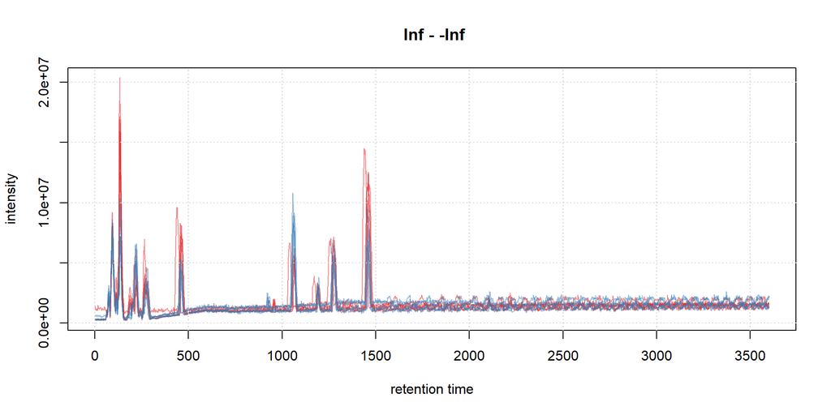

```r
bpc0 <- chromatogram(ftms, aggregationFun = "max")
plot(bpc0, col = paste0(col_sample_ftms, 80))
grid()
```

This BPC shows that there is no signal detected after 3500 seconds.

We next clean the data set filtering to a retention time range of 10-3500 seconds.

```r
ftms <- filterSpectra(ftms, filterRt, c(10, 3500))
msLevel(spectra(ftms)) |>
 table()
```

```
    1     2     3     4
20904 20907 11975  5277
```

This data contains 4 MS levels but with empty spectra so we removed them using `filterEmptySpectra()` function.

```r
ftms <- filterSpectra(ftms, filterEmptySpectra)
msLevel(spectra(ftms)) |>
  table()
```

```
    1     2     3     4
20904 20804 10695  4441
```

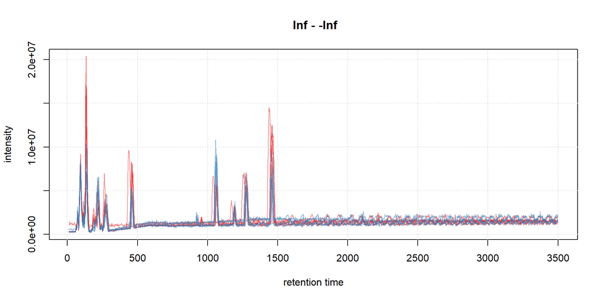

```r
bpc0 <- chromatogram(ftms, aggregationFun = "max")
plot(bpc0, col = paste0(col_sample_ftms, 80))
grid()
```

We next extract a total ion chromatogram (TIC) and base peak chromatogram (BPC) and calculate the similarities between these to evaluate similarity in the performance of the liquid chromatography.

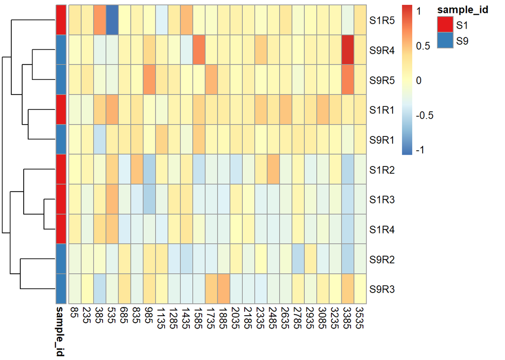

```r
#' Extract TIC
tic <- chromatogram(ftms, aggregationFun = "sum")
#' Bin the signal
ticb <- bin(tic, binSize = 150)

ticmap <- ticb |>
    lapply(intensity) |>
    do.call(what = rbind) |>
    log2()

colnames(ticmap) <- rtime(ticb[[1]])
rownames(ticmap) <- sampleData(ftms)$sample_name

#' Center the data per bin by subtracting the median
ticmap <- scale(ticmap, center = TRUE, scale = FALSE)

ann <- data.frame(sample_id = sampleData(ftms)[, "sample_id"])
rownames(ann) <- rownames(ticmap)

pheatmap(ticmap, cluster_cols = FALSE,
         annotation_colors = list(sample_id = col_sample_ftms_id),
         annotation_row = ann)
```

There is no clear separation of the signal by the seed information (S1, S9).

Now we plot the tic

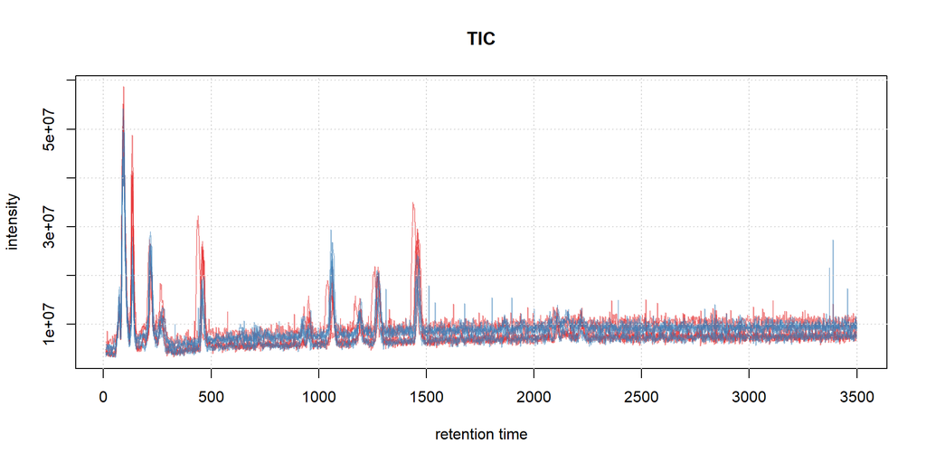

```r
plot(tic, col = paste0(col_sample_ftms, 80), main = "TIC")
grid()
```

We repeat this analysis also for the BPC.

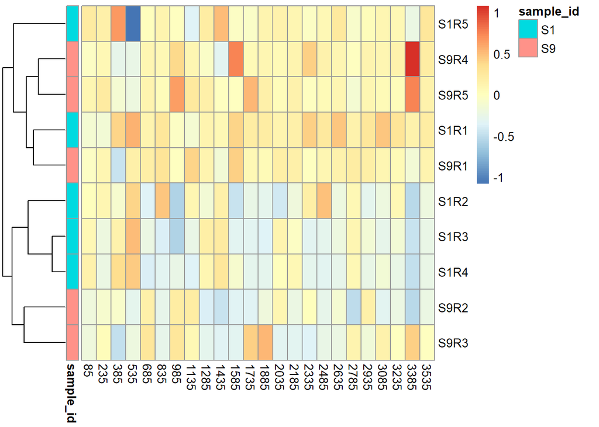

```r
#' Extract BPC
bpc <- chromatogram(ftms, aggregationFun = "sum")
#' Bin the signal
bpcb <- bin(bpc, binSize = 150)

bpcmap <- bpcb |>
    lapply(intensity) |>
    do.call(what = rbind) |>
    log2()

colnames(bpcmap) <- rtime(bpcb[[1]])
rownames(bpcmap) <- sampleData(ftms)$sample_name

#' Center the data per bin by subtracting the median
bpcmap <- scale(bpcmap, center = TRUE, scale = FALSE)
pheatmap(bpcmap, cluster_cols = FALSE,
         annotation_colors = list(sample_ftms_id = col_sample_ftms_id),
         annotation_row = ann)
```

Similar to the TIC signal, S1 and S9 samples don’t group together.

Now we plot the BPC again

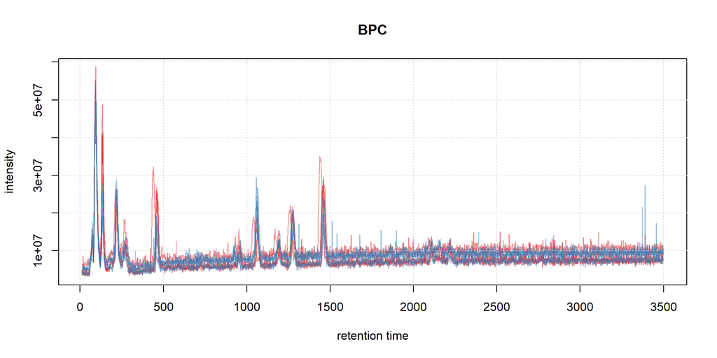

```r
plot(bpc, col = paste0(col_sample_ftms, 80), main = "BPC")
grid()
```

# Data preprocessing

## Determination of peak width parameters for chromatographic peak detection

To derive the settings for the chromatographic peak detection for the present data set we below extract the ion signal for an m/z range of a known compound.

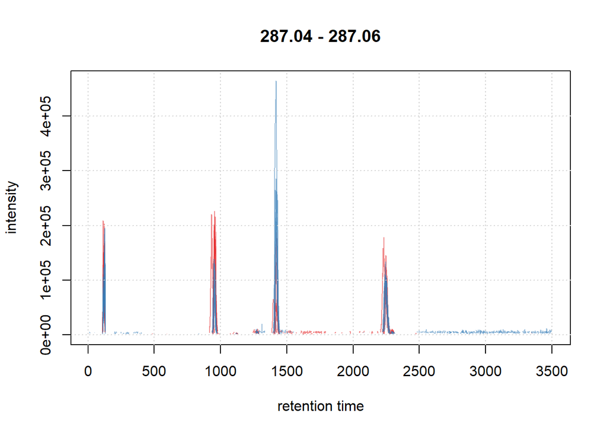

```r
mzr <- c(287.04, 287.06)

a_kn <- chromatogram(ftms, mz = mzr, aggregationFun = "max")
plot(a_kn, col = paste0(col_sample_ftms, 80))
grid()
```

We zoom into a small retention time range that contains the highest peak signal.

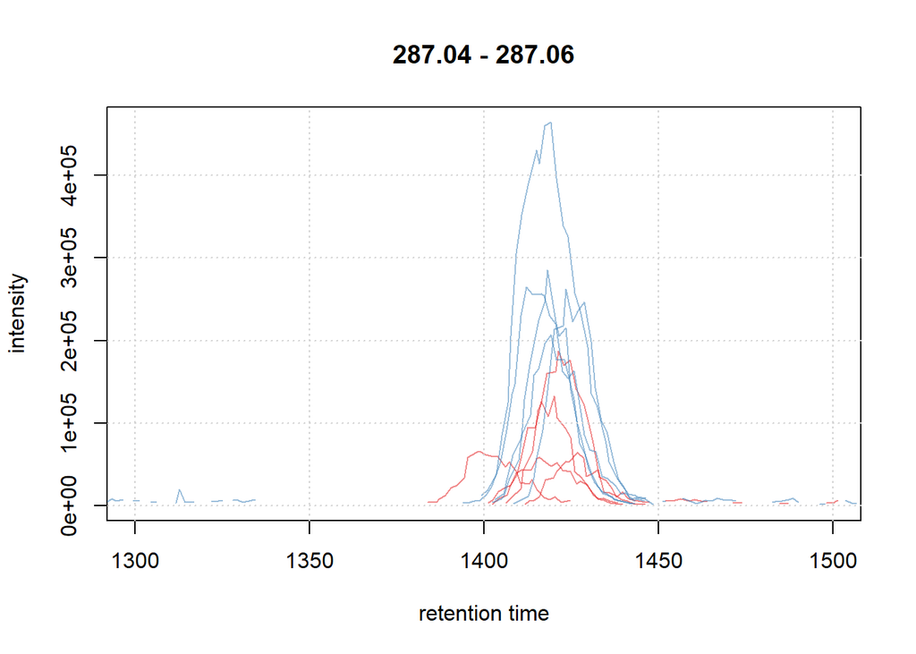

```r
#' Focus on the retention time range with the highest signal
plot(a_kn, xlim = c(1300, 1500), col = paste0(col_sample_ftms, 80))
grid()
```

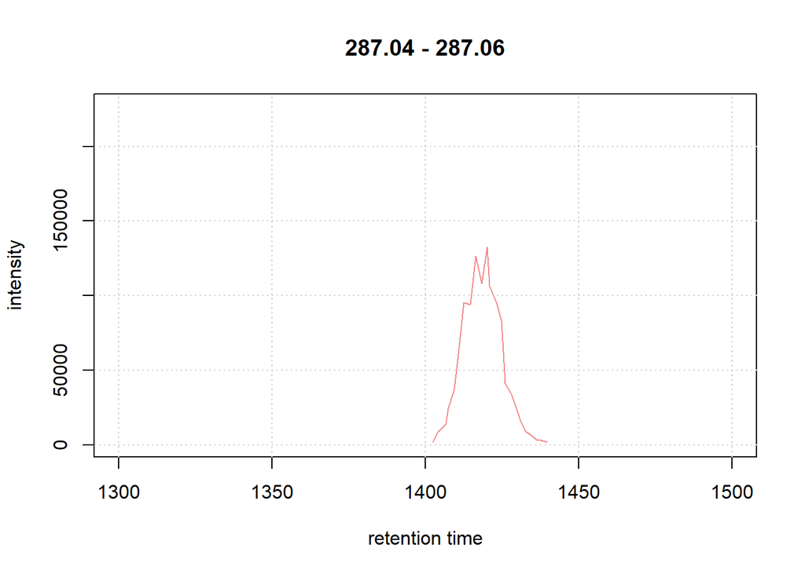

```r
#' Plot it for a single sample
plot(a_kn[, 1], xlim = c(1300, 1500),
     col = paste0(col_sample_ftms, 80))
grid()
```

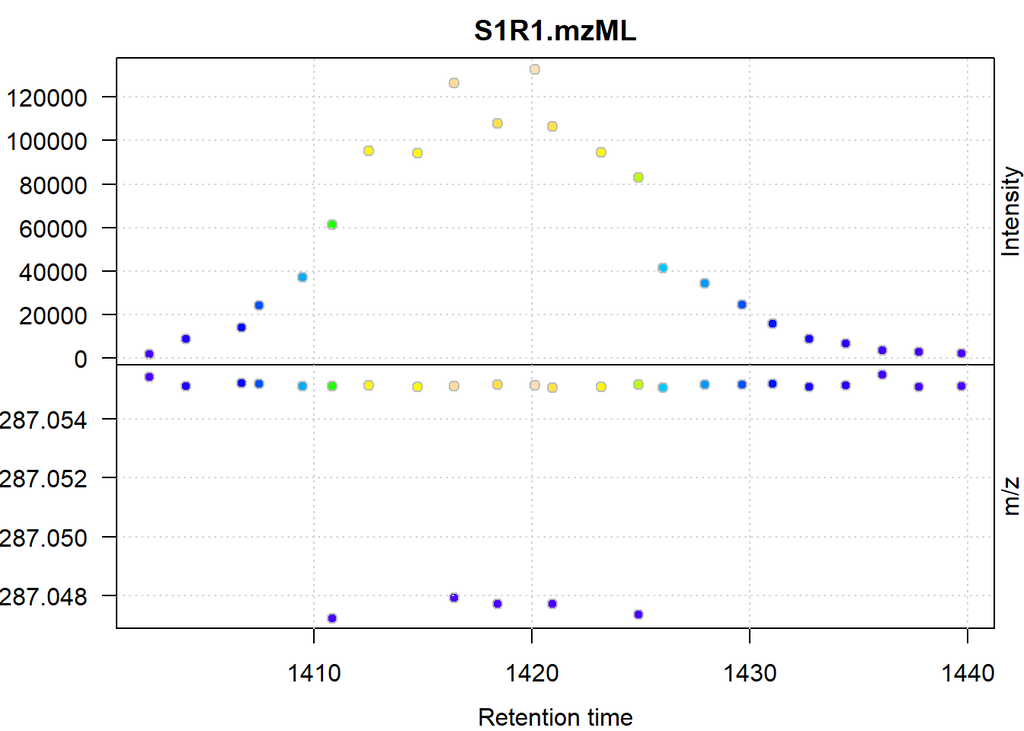

```r
tmp <- filterMz(ftms, mz = mzr) |>
    filterRt(rt = c(1400, 1440))
plot(tmp[1])
```

Here we do the same thing as qtof to choose the peakwidth parameter, but here we used the ion chromatogram of a known compound, its width is about 40 seconds so we take the half and the double - that’s 20 and 80 - as a parameter window.

Next we run the chromatographic peak detection on that extracted ion chromatogram.

```r
a_kn2 <- findChromPeaks(a_kn, CentWaveParam(peakwidth = c(20, 80),
                                            integrate = 2, snthresh = 2))
```

```r
pks <- chromPeaks(a_kn2)
head(pks)
```

```
          mz  mzmin  mzmax       rt    rtmin    rtmax        into       intb
mzmin 287.05 287.04 287.06  118.643  108.482  129.079 1580122.734 1560857.14
mzmin 287.05 287.04 287.06  197.750  194.371  201.736    5971.048    5758.66
mzmin 287.05 287.04 287.06  953.764  936.924  979.350 2984601.547 2984560.82
mzmin 287.05 287.04 287.06 1418.440 1400.740 1442.070 1941428.792 1877417.02
mzmin 287.05 287.04 287.06 2248.450 2226.720 2278.090 2691151.614 2688956.42
mzmin 287.05 287.04 287.06 2298.280 2284.030 2306.680  146283.969  145355.24
            maxo     sn row column
mzmin 163541.109     34   1      1
mzmin   1753.525      5   1      1
mzmin 226105.672 226105   1      1
mzmin 132613.359     24   1      1
mzmin 145064.109    483   1      1
mzmin  10297.019     34   1      1
```

```r
quantile(unname(pks[, "rtmax"] - pks[, "rtmin"]))
```

```
    0%    25%    50%    75%   100%
 2.790 11.915 24.885 43.565 62.870
```

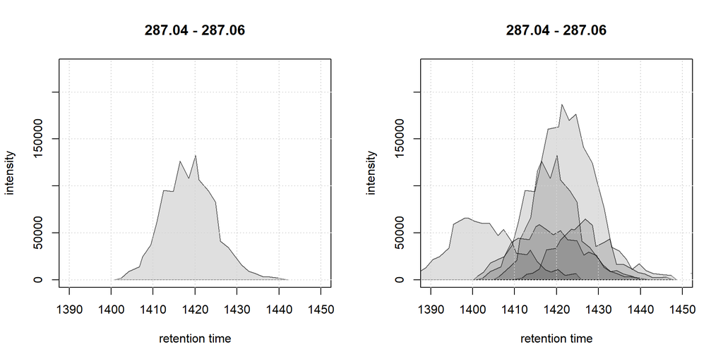

```r
par(mfrow = c(1, 2))
#' In one sample
plot(a_kn2[, 1], xlim = c(1390, 1450))
grid()
#' In five samples
plot(a_kn2[, 1:5], xlim = c(1390, 1450))
grid()
```

We repeat the same analysis on another retention time range

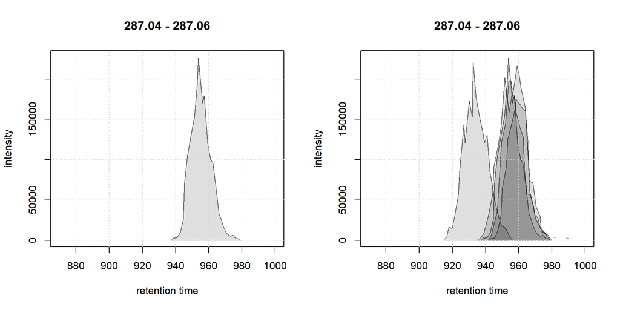

```r
par(mfrow = c(1, 2))
plot(a_kn2[, 1], xlim = c(870, 1000))
grid()
plot(a_kn2[, 1:5], xlim = c(870, 1000))
grid()
```

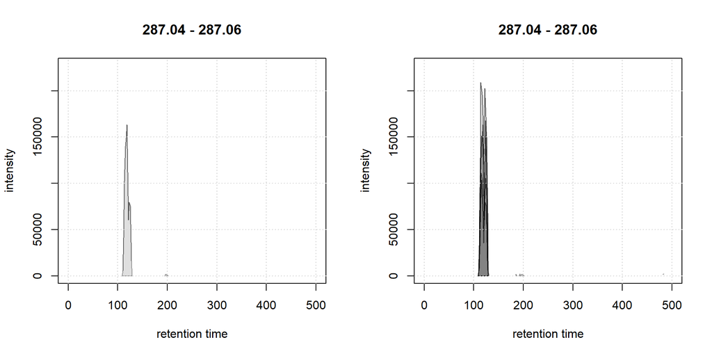

```r
par(mfrow = c(1, 2))
plot(a_kn2[, 1], xlim = c(0, 500))
grid()
plot(a_kn2[, 1:5], xlim = c(0, 500))
grid()
```

Eventually we could try another m/z range…

## Peak detection on full dataset

We next perform the chromatographic peak detection, using the centWave algorithm, on the full `MsExperiment`object, containing data of ten mzML files. With `integrate = 2` we use an alternative algorithm to correctly identify the boundaries of the identified chromatographic peaks. Parameter `chunkSize` is used to control the number of files from which the data should be loaded into memory at a time.

```r
ftms <- findChromPeaks(
    ftms, CentWaveParam(peakwidth = c(20, 80), integrate = 2, snthresh = 6,
                        ppm = 50, prefilter = c(3, 500), mzdiff = 0.001),
    chunkSize = 2)
```

The `xcms::findChromPeaks()` function transforms the `MsExperiment` object (originally created using `MsExperiment::readMsExperiment()` with mzML files and sample metadata) into an `XcmsExperiment` object.

`XcmsExperiment` is an extension of `MsExperiment`, allowing to include chromatographic peak information, alignment and grouping, all generated by core `xcms` functions.

With this setting we identified 64567 peaks in the full data set. The number of peaks per sample are:

```r
pks <- chromPeaks(ftms)
table(pks[, "sample"])
```

```
   1    2    3    4    5    6    7    8    9   10
7933 6338 7024 6917 5939 6845 6190 6318 5285 5778
```

The distribution of the peak widths in retention time and in m/z dimensions are:

```r
quantile(unname(pks[, "rtmax"] - pks[, "rtmin"]))
```

```
     0%     25%     50%     75%    100%
  6.370  13.370  19.929  28.930 117.430
```

```r
quantile(unname(pks[, "mzmax"] - pks[, "mzmin"]))
```

```
          0%          25%          50%          75%         100%
0.0000000000 0.0007731548 0.0021641542 0.0070743874 0.1085589028
```

We next perform the **chromatographic peak refinement** to reduce the number of potential centWave-specific peak detection artifacts. We choose settings that depend on the observed peak widths above (i.e., about half of the observed median widths).

```r
mnpp <- MergeNeighboringPeaksParam(expandRt = 10, expandMz = 0.001,
                                   minProp = 0.66)
ftms <- refineChromPeaks(ftms, mnpp)
```

Here we add *CleanPeaksParam* to remove chromatographic peaks with a retention time range larger than the provided maximal acceptable width (maxPeakwidth) based on (75th percentile of peak widths) * 3.

```r
rt_widths <- unname(pks[, "rtmax"] - pks[, "rtmin"])
# Compute 75th percentile and multiply by 3
peakwidth <- quantile(rt_widths, 0.75) * 3
cpp <- CleanPeaksParam(maxPeakwidth = peakwidth)

ftms <- refineChromPeaks(ftms, cpp)
```

We evaluate the number of peaks and the observed peak widths also after refinement.

```r
pks <- chromPeaks(ftms)
nrow(pks)
```

```
[1] 59033
```

```r
table(pks[, "sample"])
```

```
   1    2    3    4    5    6    7    8    9   10
7009 6012 6293 6199 5484 6372 5781 5679 4716 5488
```

```r
quantile(unname(pks[,"rtmax"] - pks[,"rtmin"]))
```

```
    0%    25%    50%    75%   100%
 6.370 12.976 18.930 26.926 86.750
```

```r
quantile(unname(pks[,"mzmax"] - pks[,"mzmin"]))
```

```
          0%          25%          50%          75%         100%
0.0000000000 0.0007816152 0.0020271816 0.0064470030 0.5278583466
```

```r
beta_metrics <- chromPeakSummary(ftms, param = BetaDistributionParam())
colnames(beta_metrics)
```

```
[1] "beta_cor" "beta_snr"
```

```r
summary(beta_metrics[, "beta_cor"])
```

```
   Min. 1st Qu.  Median    Mean 3rd Qu.    Max.    NA's
-0.9512  0.4378  0.7333  0.6177  0.8965  1.0000    8121
```

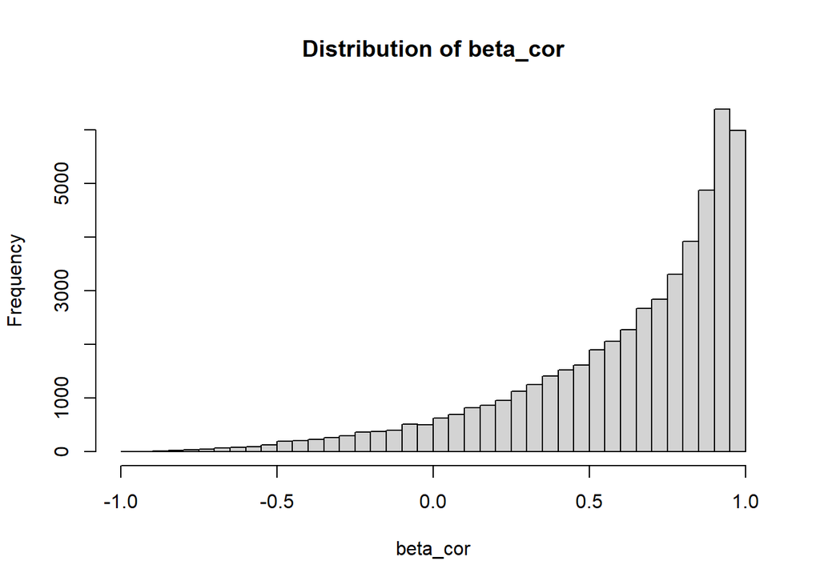

```r
hist(beta_metrics[, "beta_cor"], breaks = 50,
     main = "Distribution of beta_cor", xlab = "beta_cor")
```

`beta_cor` ranges from -1.0 to 1.0 and has median 0.7333467. Most peaks thus have a `beta-cor`close to 1. Negative beta_cor values indicate anti-correlation of observed signal with Gaussian-like model. These peaks seem to have a valley instead of an apex, maybe multiple shoulders or just baseline fluctuation. Peaks with **negative beta_cor must be filtered out**. But we could first refine the peaks and evaluate the beta_cor values again after refinement before filtering.

```r
#' silently plotting and saving examples for good, intermediate and bad quality
set.seed(123)
#' Selecting 12 random peaks with a negative beta_cor
cid <- rownames(beta_metrics)[which(beta_metrics[, "beta_cor"] < -0.5)] |>
    sample(size = 12)
eics <- chromPeakChromatograms(ftms, peaks = cid)
#' Saving the EICs to a file
dr <- file.path("images", "chrom_peak_evaluation")
dir.create(dr, recursive = TRUE, showWarnings = FALSE)
png(filename = file.path(dr, "chrom_peaks_negative_beta_cor.png"),
    width = 15, height = 15, units = "cm", res = 600, pointsize = 6)
plot(eics)
dev.off()
```

```r
#' Selecting 12 random peaks with beta_cor around 0
cid <- rownames(beta_metrics)[which(beta_metrics[, "beta_cor"] > -0.2 &
                                    beta_metrics[, "beta_cor"] < 0.2)] |>
    sample(size = 12)
eics <- chromPeakChromatograms(ftms, peaks = cid)
#' Saving the EICs to a file
png(filename = file.path(dr, "chrom_peaks_0_beta_cor.png"),
    width = 15, height = 15, units = "cm", res = 600, pointsize = 6)
plot(eics)
dev.off()
```

```r
#' Selecting 12 random peaks with beta_cor around 1
cid <- rownames(beta_metrics)[which(beta_metrics[, "beta_cor"] > 0.9)] |>
    sample(size = 12)
eics <- chromPeakChromatograms(ftms, peaks = cid)
#' Saving the EICs to a file
png(filename = file.path(dr, "chrom_peaks_1_beta_cor.png"),
    width = 15, height = 15, units = "cm", res = 600, pointsize = 6)
plot(eics)
dev.off()
```

```r
#' Selecting 12 peaks with a NA beta cor
cid <- rownames(beta_metrics)[is.na(beta_metrics[, "beta_cor"])] |>
    sample(size = 12)
eics <- chromPeakChromatograms(ftms, peaks = cid)
#' Saving the EICs to a file
png(filename = file.path(dr, "chrom_peaks_NA_beta_cor.png"),
    width = 15, height = 15, units = "cm", res = 600, pointsize = 6)
plot(eics)
dev.off()
```

Now we want to filter out junk peaks based on `beta_cor < 0`. This will remove 3847 peaks with a negative beta correlation and 8121 peaks with a missing beta correlation value of the in total 59033 chromatographic peaks.

```r
#' Keep only chrom peaks with a positive correlation, removing also those
#' with a missing value.
ftms <- filterChromPeaks(ftms, keep = which(beta_metrics[, "beta_cor"] > 0))
```

We evaluate the number of peaks and the observed peak widths.

```r
pks <- chromPeaks(ftms)
nrow(pks)
```

```
[1] 47065
```

```r
table(pks[, "sample"])
```

```
   1    2    3    4    5    6    7    8    9   10
5590 4827 4999 4896 4358 5098 4692 4548 3688 4369
```

```r
quantile(unname(pks[,"rtmax"] - pks[,"rtmin"]))
```

```
    0%    25%    50%    75%   100%
 7.790 15.679 21.086 28.980 86.750
```

```r
quantile(unname(pks[,"mzmax"] - pks[,"mzmin"]))
```

```
          0%          25%          50%          75%         100%
2.000398e-05 7.507759e-04 1.817755e-03 5.756316e-03 5.278583e-01
```

## Retention time alignment

We next perform an initial correspondence analysis that is needed for the subsequent retention time alignment. We evaluate the settings on the example m/z range from above.

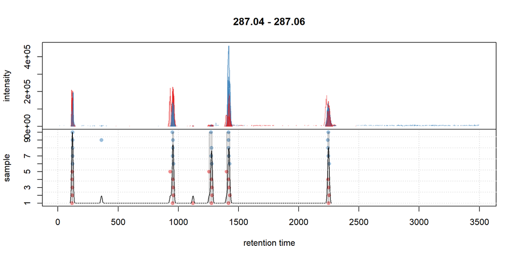

```r
#' Extract the ion chromatogram again.
a_2 <- chromatogram(ftms, aggregationFun = "max", mz = mzr)

#' Configure settings
pdp <- PeakDensityParam(sampleGroups = sampleData(ftms)$sample_id,
                        bw = 6, minFraction = 0.3, binSize = 0.1,
                        ppm = 10)
#' Evaluate settings on the full range
plotChromPeakDensity(
    a_2, param = pdp, col = paste0(col_sample_ftms, 80),
    peakCol = paste0(col_sample_ftms[chromPeaks(a_2)[, "sample"]], 80),
    peakBg = paste0(col_sample_ftms[chromPeaks(a_2)[, "sample"]], 40),
    peakPch = 16)
grid()
```

We focus on a smaller retention time range:

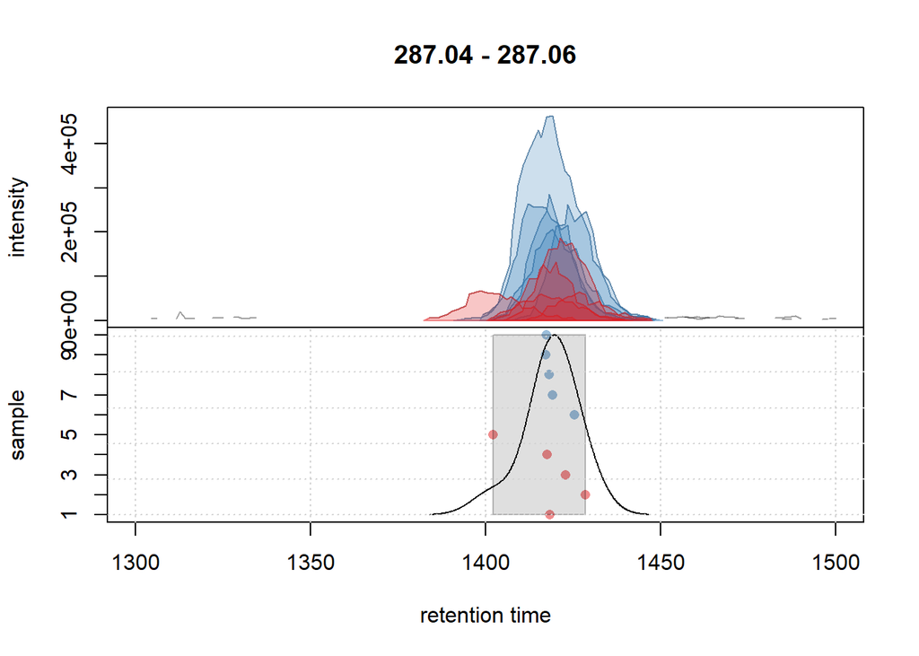

```r
a_sub <- filterRt(a_2, rt = c(1300, 1500))
plotChromPeakDensity(
    a_sub, param = pdp,
    peakCol = paste0(col_sample_ftms[chromPeaks(a_sub)[, "sample"]], 80),
    peakBg = paste0(col_sample_ftms[chromPeaks(a_sub)[, "sample"]], 40),
    peakPch = 16)
grid()
```

Correspondence with the selected settings seems to correctly group features.

```r
ftms <- groupChromPeaks(ftms, param = pdp)
```

We next perform retention time alignment:

```r
pgp <- PeakGroupsParam(
    minFraction = 0.9,
    extraPeaks = 100,
    smooth = "loess",
    span = 0.4,
    family = "gaussian"
)
ftms <- adjustRtime(ftms, param = pgp)
```

Below we plot the results from the retention time alignment, i.e., the difference between the original and adjusted retention times (y-axis) along the retention time axis (x-axis).

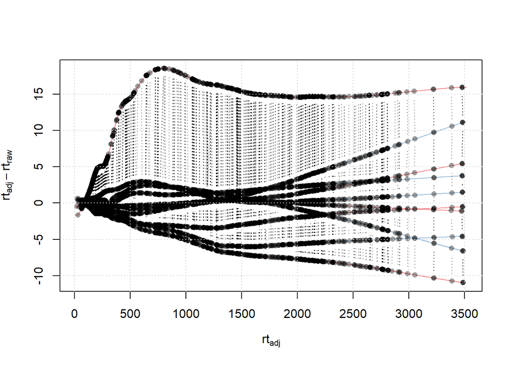

```r
plotAdjustedRtime(ftms, col = paste0(col_sample_ftms, 80))
grid()
```

We can see from the plot above that there is one sample that has been largely adjusted, so it goes up to 15 seconds.

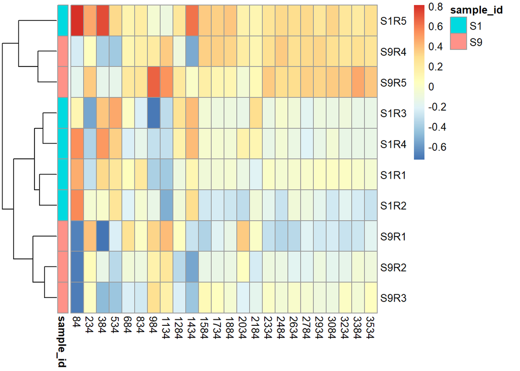

```r
bpc_adj <- chromatogram(ftms, aggregationFun = "max")
#' Calculate similarity (Pearson correlation) between BPCs
#' Bin the signal
bpcb <- bin(bpc_adj, binSize = 150)

bpcmap <- bpcb |>
    lapply(intensity) |>
    do.call(what = rbind)

bpcmap[bpcmap <= 0] <- NA

bpcmap <- log2(bpcmap)

colnames(bpcmap) <- rtime(bpcb[[1]])
rownames(bpcmap) <- sampleData(ftms)$sample_name

#' Center the data per bin by subtracting the median
bpcmap <- scale(bpcmap, center = TRUE, scale = FALSE)
pheatmap(bpcmap, cluster_cols = FALSE,
         annotation_colors = list(sample_ftms_id = col_sample_ftms_id),
         annotation_row = ann)
```

we see that S1 and S9 are well grouped after retention time alignment.

Now we can visualize the changes before and after retention time alignment

```r
bpc_adj <- chromatogram(ftms, aggregationFun = "max", chromPeaks = "none")
a_adj <- chromatogram(ftms, aggregationFun = "max", mz = mzr)
```

We first plot the BPC of the original data and then of the data after retention time alignment.

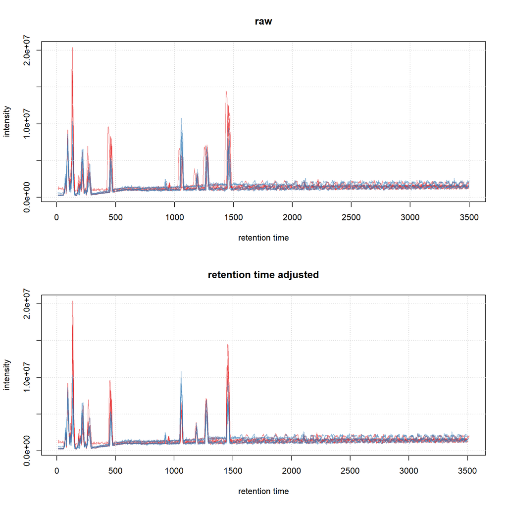

```r
par(mfrow = c(2, 1))
plot(bpc0, col = paste0(col_sample_ftms, 80), main = "raw")
grid()
plot(bpc_adj, col = paste0(col_sample_ftms, 80),
     main = "retention time adjusted")
grid()
```

And we plot them also separately

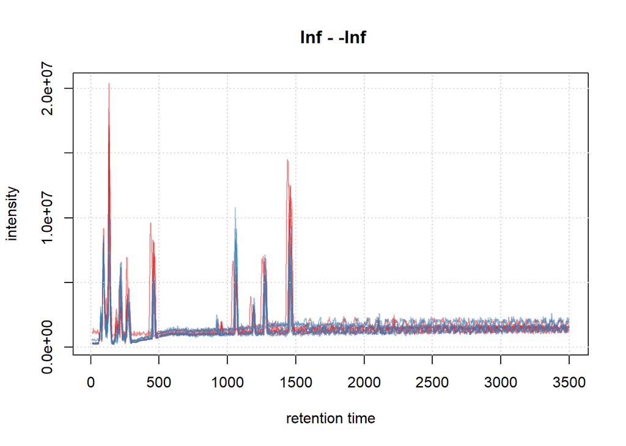

```r
par(mfrow = c(1, 1))
plot(bpc0, col = paste0(col_sample_ftms, 80))
grid()
```

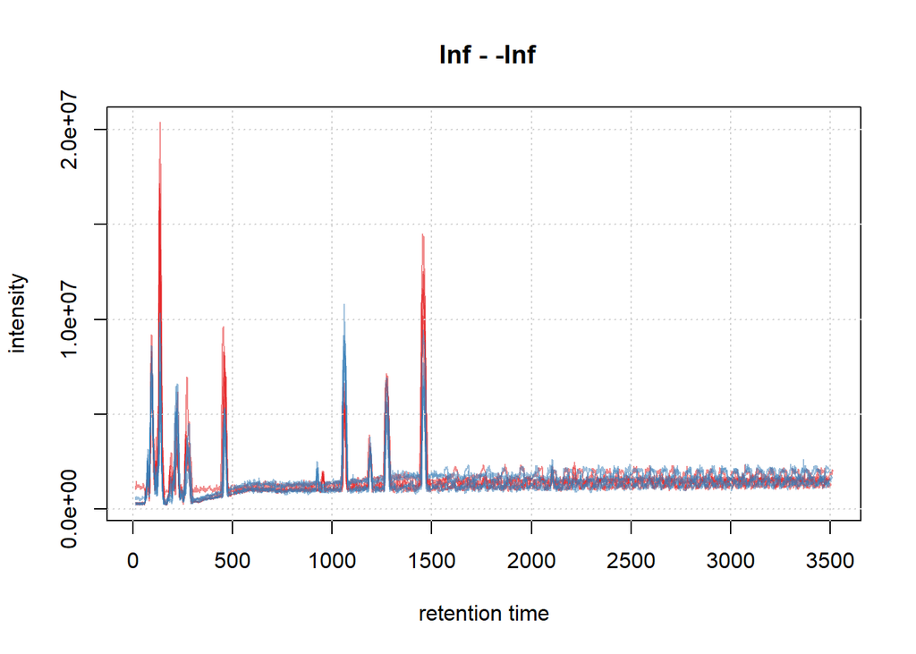

```r
par(mfrow = c(1, 1))
plot(bpc_adj, col = paste0(col_sample_ftms, 80))
grid()
```

The data looks well aligned, next we need to visualize the alignment result on a smaller retention time range.

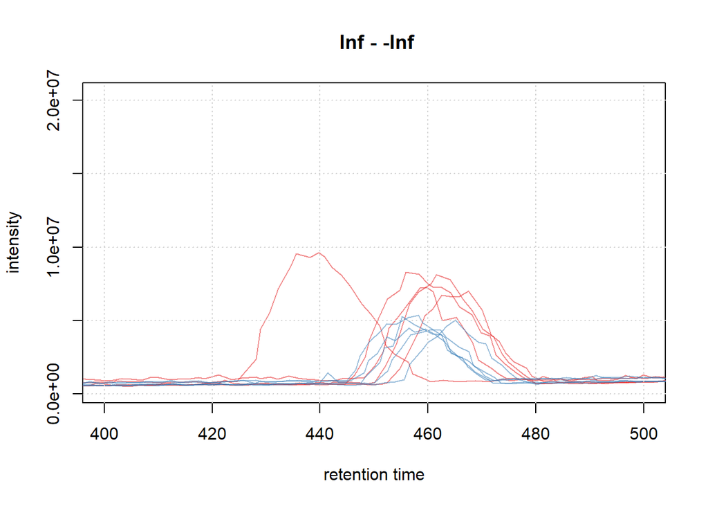

```r
par(mfrow = c(1, 1))
plot(bpc0, col = paste0(col_sample_ftms, 80), xlim = c(400, 500))
grid()
```

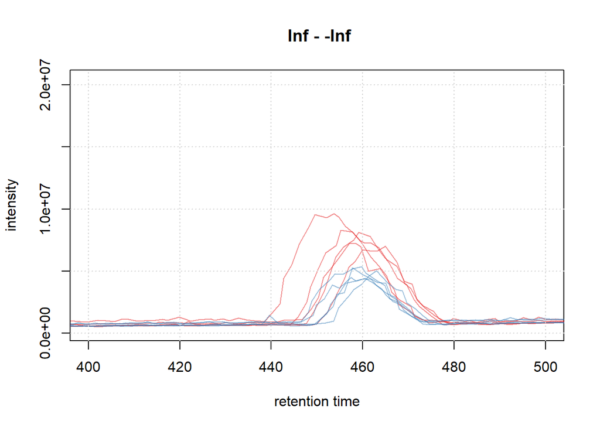

```r
par(mfrow = c(1, 1))
plot(bpc_adj, col = paste0(col_sample_ftms, 80), xlim = c(400, 500))
grid()
```

The data looks well aligned, From this results we can conclude that retention time alignment works well on this data.

We in addition evaluate the signal for the example m/z range.

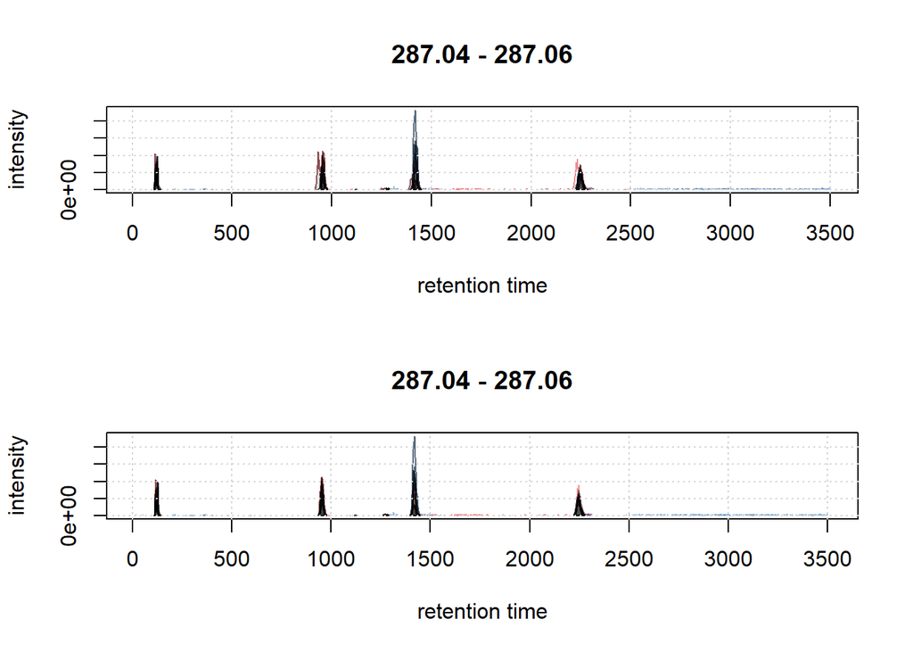

```r
par(mfrow = c(2, 1))
plot(a_2, col = paste0(col_sample_ftms, 80))
grid()
plot(a_adj, col = paste0(col_sample_ftms, 80))
grid()
```

the data seems to be better aligned. Finally, we zoom into a retention time window from 1300 to 1500 seconds.

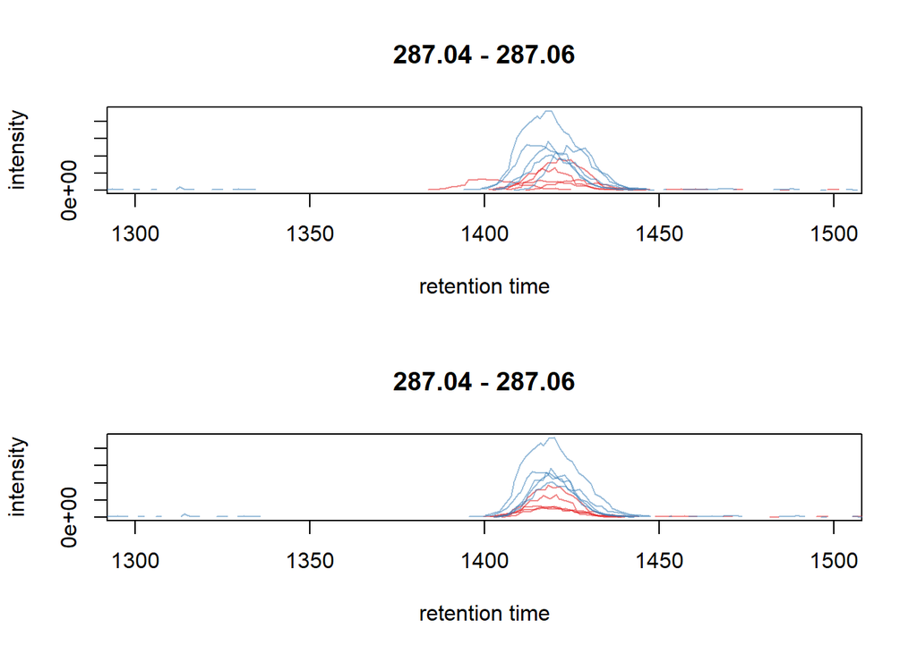

```r
par(mfrow = c(2, 1))
plot(a_2, col = paste0(col_sample_ftms, 80), peakType = "none",
     xlim = c(1300, 1500))
plot(a_adj, col = paste0(col_sample_ftms, 80),
     xlim = c(1300, 1500), peakType = "none")
```

We can thus conclude that the settings for the retention time alignment worked on the present data set. We continue the preprocessing with the final correspondence analysis. We adapt now the settings, in particular the bw parameter, that can be much stricter because of the properly aligned data set. Again, we test the settings on the extracted ion signal.

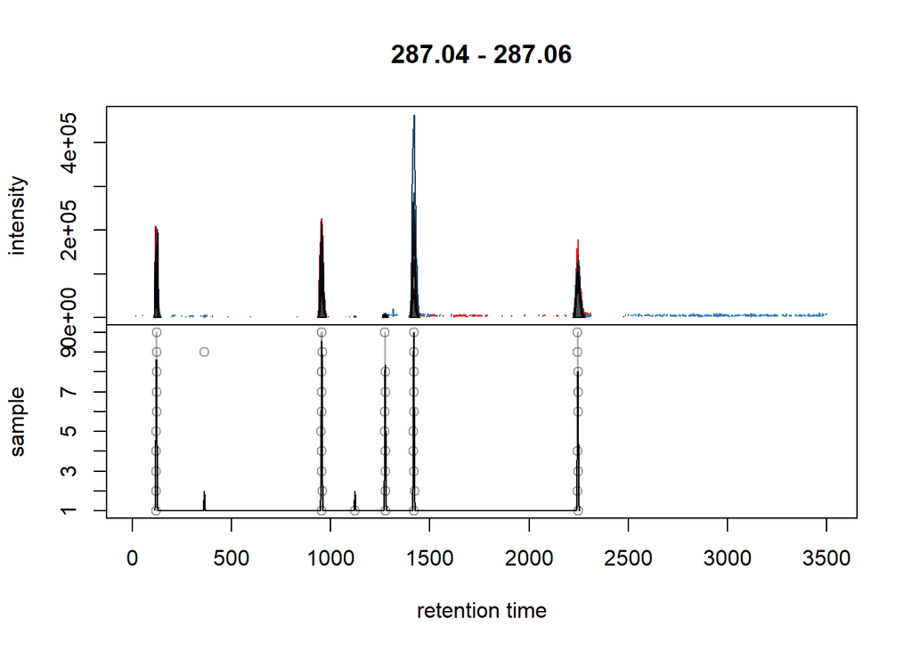

```r
#' Configure settings
pdp <- PeakDensityParam(sampleGroups = sampleData(ftms)$sample_id,
                        bw = 2, minFraction = 0.3, binSize = 0.1,
                        ppm = 10)

#' Evaluate settings on the full range
plotChromPeakDensity(a_adj, param = pdp, col = col_sample_ftms)
```

We zoom into a smaller region with multiple peaks

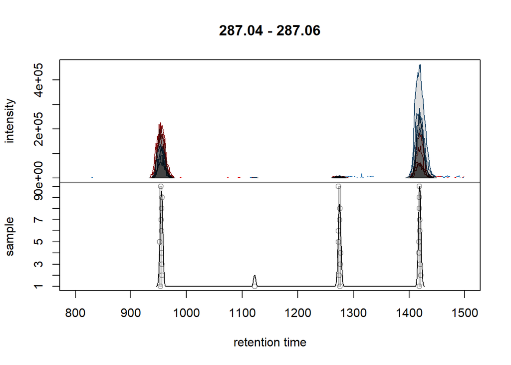

```r
a_adj_2 <- filterRt(a_adj, c(800, 1500))
plotChromPeakDensity(a_adj_2, param = pdp, col = col_sample_ftms)
```

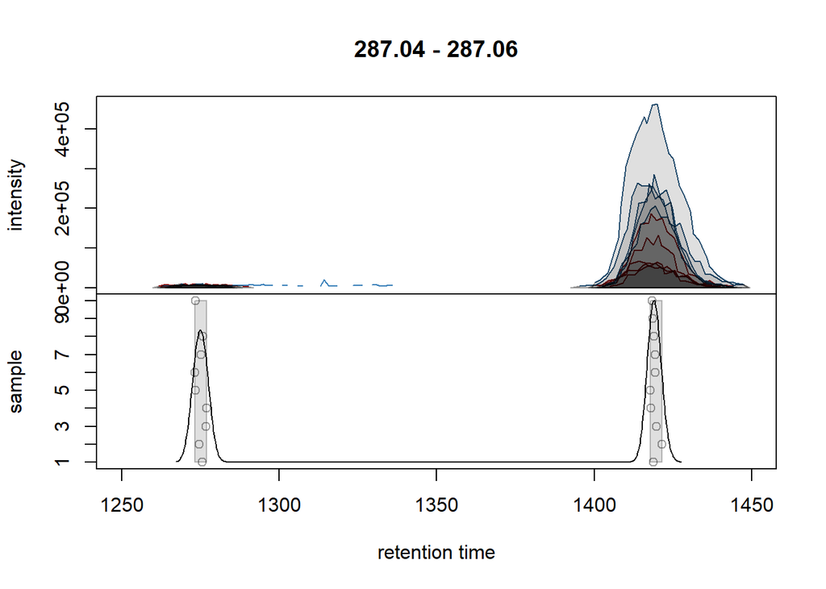

```r
a_adj_2 <- filterRt(a_adj, c(1250, 1450))
plotChromPeakDensity(a_adj_2, param = pdp, col = col_sample_ftms)
```

now we group chromatographic peaks

```r
ftms <- groupChromPeaks(ftms, param = pdp)
```

As a final step we next perform gap-filling to reduce the number of missing values in the data set.

```r
#' The number of missing values before gap filling
sum(is.na(featureValues(ftms)))
```

```
[1] 23892
```

```r
head(featureValues(ftms))
```

```
       S1R1.mzML S1R2.mzML S1R3.mzML S1R4.mzML S1R5.mzML S9R1.mzML S9R2.mzML
FT0001  20052.63  50262.87  64525.61  20796.19  99082.91  55519.14  54200.21
FT0002  25044.82  74891.04  77730.83  90570.77  63265.32  68471.00  63351.29
FT0003        NA  24027.34        NA 110181.71 327810.80        NA 507943.82
FT0004        NA  39075.68  30037.75        NA        NA  28526.13        NA
FT0005        NA  33855.64  45990.79  52148.39        NA        NA        NA
FT0006        NA        NA        NA        NA        NA  46934.90  69681.08
       S9R3.mzML  S9R4.mzML  S9R5.mzML
FT0001  43162.15   29953.73   69147.68
FT0002  75646.88   78697.95   91205.02
FT0003 805824.34 1118750.65 1365930.85
FT0004        NA         NA         NA
FT0005        NA         NA         NA
FT0006  53335.69         NA         NA
```

```r
#' Perform gap-filling
ftms <- fillChromPeaks(ftms, param = ChromPeakAreaParam())
```

```r
sum(is.na(featureValues(ftms)))
```

```
[1] 7160
```

```r
head(featureValues(ftms))
```

```
       S1R1.mzML S1R2.mzML S1R3.mzML S1R4.mzML  S1R5.mzML S9R1.mzML S9R2.mzML
FT0001 20052.631  50262.87 64525.610  20796.19  99082.909  55519.14  54200.21
FT0002 25044.816  74891.04 77730.831  90570.77  63265.316  68471.00  63351.29
FT0003  2254.594  24027.34 82317.112 110181.71 327810.796  92739.78 507943.82
FT0004 15507.435  39075.68 30037.746        NA   7737.248  28526.13        NA
FT0005 16572.698  33855.64 45990.786  52148.39         NA        NA        NA
FT0006  6176.358  19676.38  4829.504        NA   6918.430  46934.90  69681.08
       S9R3.mzML  S9R4.mzML  S9R5.mzML
FT0001  43162.15   29953.73   69147.68
FT0002  75646.88   78697.95   91205.02
FT0003 805824.34 1118750.65 1365930.85
FT0004  17815.42         NA   20647.58
FT0005        NA         NA   12850.32
FT0006  53335.69   34117.94   56432.26
```

```r
#' Save the result object
save(ftms, file = file.path(pth, "data", "ftms.RData"))
```

```r
tol <- 1e-6
featureDefinitions(ftms)[
  !is.na(featureDefinitions(ftms)$mzmed) &
  featureDefinitions(ftms)$mzmed > 137.023 &
  featureDefinitions(ftms)$mzmed < 137.025, ]
```

```
          mzmed    mzmin    mzmax     rtmed     rtmin     rtmax npeaks S1 S9
FT0070 137.0243 137.0006 137.0478  721.6795  719.3584  724.9795     29  5  5
FT0071 137.0244 137.0239 137.0246  257.8902  254.7266  262.4424     10  5  5
FT0073 137.0242 137.0242 137.0243 1458.6875 1457.2109 1460.1641      2  2  0
            peakidx ms_level
FT0070 2906, 29....        1
FT0071 1987, 74....        1
FT0073 9181, 13....        1
```

```r
nrow(featureDefinitions(ftms))
```

```
[1] 5936
```

```r
msLevel(spectra(ftms)) |>
  table()
```

```
    1     2     3     4
20904 20804 10695  4441
```

We next save the raw and adjusted BPC to a image file.

```r
#' Define the file path where to save the image
dr <- "images/ftms_glob/"
dir.create(dr, showWarnings = FALSE, recursive = TRUE)
png(file.path(dr, "ftms-bpc-aligned_sh_min.png"), width = 14, height = 10,
    units = "cm", res = 600, pointsize = 4)

par(mfrow = c(2, 1))
plot(bpc0, col = paste0(col_sample_ftms, 80), main = "Raw data")
grid()
plot(bpc_adj, col = paste0(col_sample_ftms, 80),
     main = "Retention time aligned")
grid()

dev.off()
```

# Session information